# Species-level CLR-PCA of longitudinal full-length 16S profiles

This analysis applies a centered log-ratio transformation followed by principal component analysis to species-level full-length 16S profiles. Selected longitudinal time groups are visualized with group-specific colors, confidence ellipses, and consistent coordinate ranges.

```r
required_packages <- c("factoextra", "ggplot2", "ggpubr")
missing_packages <- required_packages[
  !vapply(required_packages, requireNamespace, logical(1), quietly = TRUE)
]
if (length(missing_packages) > 0L) {
  stop(
    "Install the following R packages before running this analysis: ",
    paste(missing_packages, collapse = ", ")
  )
}

input_file <- "000.input16S.Rds"
analysis_name <- "02.16sPCoA"
output_root <- analysis_name
figure_dir <- file.path(output_root, "figures")

dir.create(output_root, recursive = TRUE, showWarnings = FALSE)
dir.create(figure_dir, recursive = TRUE, showWarnings = FALSE)

# Keep all automatically generated R Markdown figures under the same output
# directory as the explicitly saved PDF files.
knitr::opts_chunk$set(
  fig.path = file.path(output_root, "knitr_figures", "")
)

group_levels <- c(
  "001_BL", "002_D0", "003_D14", "004_M1",
  "005_M2", "006_M3", "009_M6"
)

group_colors <- c(
  "001_BL" = "#969696",
  "002_D0" = "#feb24c",
  "003_D14" = "#ff0000",
  "004_M1" = "#7fc97f",
  "005_M2" = "#beaed4",
  "006_M3" = "#007A87",
  "009_M6" = "#c51b8a"
)
```

# 1 1. Read and align the de-identified input

The abundance matrix already uses `Sample_Name` as its column names. Only the sample name and longitudinal group are required for this analysis; the unused metadata join and coefficient-of-variation calculation from the exploratory script have therefore been removed.

```r
if (!file.exists(input_file)) {
  stop("Input file not found: ", input_file)
}

input16S <- readRDS(input_file)
if (!is.list(input16S) || !all(c("dat_rela", "metainfo") %in% names(input16S))) {
  stop("000.input16S.Rds must contain dat_rela and metainfo.")
}

dat_rela <- input16S$dat_rela
metainfo <- input16S$metainfo

required_metadata <- c("Sample_Name", "timeIDcontiue")
missing_metadata <- setdiff(required_metadata, names(metainfo))
if (length(missing_metadata) > 0L) {
  stop("metainfo is missing required column(s): ", paste(missing_metadata, collapse = ", "))
}

if (!identical(colnames(dat_rela), as.character(metainfo$Sample_Name))) {
  stop("dat_rela columns are not aligned with metainfo$Sample_Name.")
}
if (anyDuplicated(metainfo$Sample_Name) || anyDuplicated(colnames(dat_rela))) {
  stop("Sample_Name must be unique in both dat_rela and metainfo.")
}

keep_samples <- metainfo$timeIDcontiue %in% group_levels
metainfo_select <- metainfo[keep_samples, c("Sample_Name", "timeIDcontiue"), drop = FALSE]
metainfo_select$timeIDcontiue <- as.character(metainfo_select$timeIDcontiue)

dat_rela_select <- dat_rela[, metainfo_select$Sample_Name, drop = FALSE]
dat_rela_select <- dat_rela_select[rowSums(dat_rela_select) > 0, , drop = FALSE]

stopifnot(
  ncol(dat_rela_select) == nrow(metainfo_select),
  identical(colnames(dat_rela_select), as.character(metainfo_select$Sample_Name)),
  !anyNA(metainfo_select$timeIDcontiue)
)

data.frame(
  time_group = group_levels,
  n_samples = as.integer(
    table(factor(metainfo_select$timeIDcontiue, levels = group_levels))
  )
)
```

```
##   time_group n_samples
## 1     001_BL        28
## 2     002_D0        19
## 3    003_D14        26
## 4     004_M1        32
## 5     005_M2        22
## 6     006_M3        24
## 7     009_M6        12
```

# 2 2. CLR transformation and PCA

A pseudocount of `1e-6` is added before applying the centered log-ratio (CLR) transformation independently to each sample. PCA is then performed on samples, with centering enabled and scaling disabled.

```r
pseudo <- 1e-6

dat_clr <- apply(
  dat_rela_select + pseudo,
  2,
  function(x) log(x) - mean(log(x))
)

pcs <- stats::prcomp(
  t(dat_clr),
  center = TRUE,
  scale. = FALSE
)
```

# 3 3. PCA of all selected longitudinal groups

The full plot retains the original seven-color palette and 95% confidence ellipses. The output dimensions remain 4.96 by 3.71 inches.

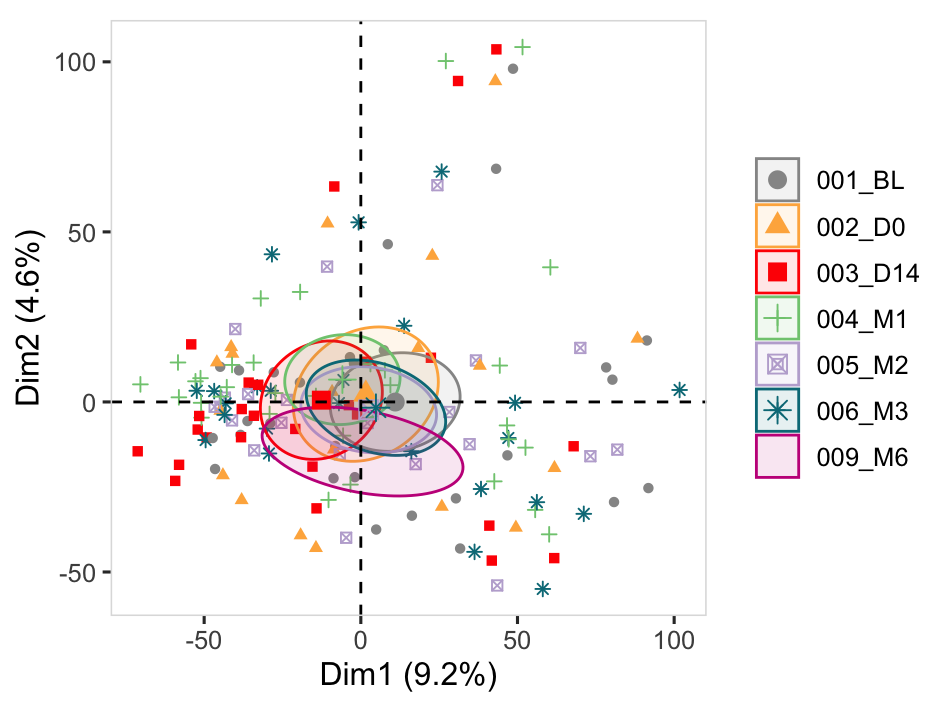

```r
p_all <- factoextra::fviz_pca_ind(
  pcs,
  geom = "point",
  col.ind = metainfo_select$timeIDcontiue,
  palette = unname(group_colors),
  addEllipses = TRUE,
  ellipse.type = "confidence",
  ellipse.level = 0.95,
  legend.title = "Groups",
  repel = TRUE
) +
  ggplot2::theme_bw(12) +
  ggplot2::theme(
    aspect.ratio = 1,
    legend.title = ggplot2::element_blank(),
    plot.title = ggplot2::element_blank(),
    axis.text = ggplot2::element_text(family = "ArialMT"),
    axis.title = ggplot2::element_text(family = "ArialMT"),
    panel.grid = ggplot2::element_blank(),
    panel.border = ggplot2::element_rect(fill = NA, colour = "grey87")
  )

all_groups_pdf <- file.path(
  figure_dir,
  "species_clr_pca_all_timepoints.pdf"
)

ggplot2::ggsave(
  all_groups_pdf,
  p_all,
  width = 4.96,
  height = 3.71,
  device = "pdf"
)

p_all
```

# 4 4. Baseline-versus-timepoint PCA panels

All pairwise panels use the PCA scores calculated from the complete selected dataset. They therefore share one coordinate system. As in the original code, the lower x-axis limit is fixed at -80, points use shape 21, and the group ellipses use a 68% t-distribution level.

```r
df_all <- p_all$data
df_all$timeIDcontiue <- df_all$Col.

# Use the same global coordinate limits for all six panels.
x_range <- range(df_all$x, na.rm = TRUE)
x_range[1] <- -80
y_range <- range(df_all$y, na.rm = TRUE)

pair_levels <- c(
  "002_D0", "003_D14", "004_M1",
  "005_M2", "006_M3", "009_M6"
)

plot_pair_from_all_pca <- function(timepoint) {
  pair_data <- subset(
    df_all,
    timeIDcontiue %in% c("001_BL", timepoint)
  )
  pair_data$group_pair <- ifelse(
    pair_data$timeIDcontiue == "001_BL",
    "001_BL",
    timepoint
  )

  ggplot2::ggplot(
    pair_data,
    ggplot2::aes(x = x, y = y, fill = group_pair)
  ) +
    ggplot2::geom_point(
      shape = 21,
      color = "black",
      size = 1,
      stroke = 0.3
    ) +
    ggplot2::stat_ellipse(
      ggplot2::aes(color = group_pair),
      type = "t",
      level = 0.68,
      linewidth = 0.5,
      show.legend = FALSE
    ) +
    ggplot2::geom_vline(xintercept = 0, linetype = "dashed") +
    ggplot2::geom_hline(yintercept = 0, linetype = "dashed") +
    ggplot2::scale_fill_manual(values = group_colors) +
    ggplot2::scale_color_manual(values = group_colors) +
    ggplot2::coord_cartesian(
      xlim = x_range,
      ylim = y_range,
      expand = FALSE
    ) +
    ggplot2::theme_bw(12) +
    ggplot2::theme(
      aspect.ratio = 1,
      legend.position = "none",
      legend.title = ggplot2::element_blank(),
      axis.title = ggplot2::element_blank(),
      plot.title = ggplot2::element_text(hjust = 0.5),
      panel.grid = ggplot2::element_blank(),
      panel.border = ggplot2::element_rect(fill = NA, colour = "grey87")
    )
}

pair_plots <- lapply(pair_levels, plot_pair_from_all_pca)
names(pair_plots) <- paste0("baseline_vs_", sub("^\\d+_", "", tolower(pair_levels)))
```

```r
for (plot_name in names(pair_plots)) {
  output_file <- file.path(
    figure_dir,
    paste0("species_clr_pca_", plot_name, ".pdf")
  )

  ggplot2::ggsave(
    output_file,
    pair_plots[[plot_name]],
    width = 5.5,
    height = 5.5,
    device = "pdf"
  )
}
```

# 5 5. Combined six-panel figure

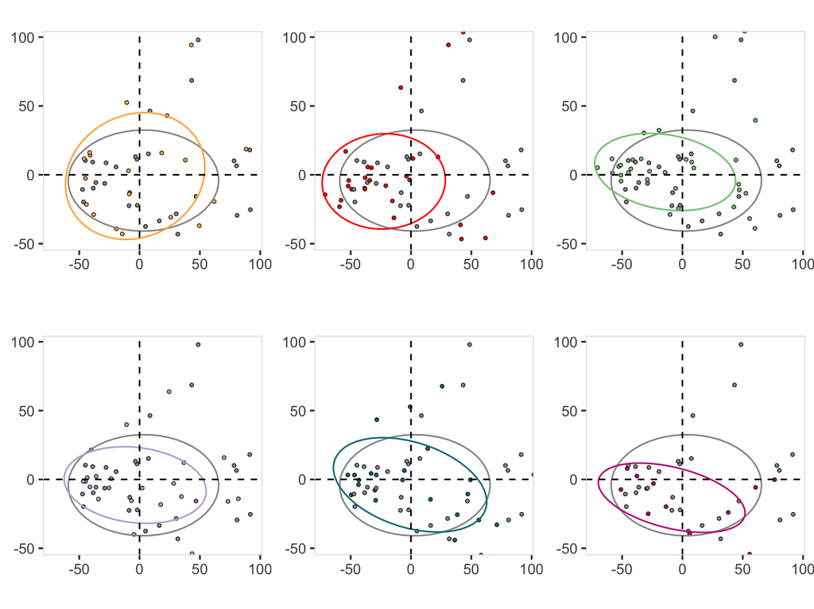

```r
p_combined <- ggpubr::ggarrange(
  pair_plots[["baseline_vs_d0"]],
  pair_plots[["baseline_vs_d14"]],
  pair_plots[["baseline_vs_m1"]],
  pair_plots[["baseline_vs_m2"]],
  pair_plots[["baseline_vs_m3"]],
  pair_plots[["baseline_vs_m6"]],
  align = "hv"
)

combined_pdf <- file.path(
  figure_dir,
  "species_clr_pca_baseline_pairwise_panels.pdf"
)

ggplot2::ggsave(
  combined_pdf,
  p_combined,
  width = 4.96 * 1.5,
  height = 3.71 * 1.5,
  device = "pdf"
)

p_combined
```